# Lectures 8 and 9

# ARIMA models

```r
library(fpp3)
```

Autoregressive integrated moving average. 3 terms in model(AR, I, MA).

AR = autoregressive = lagged observations as inputs I = integrated = differencing to make series stationary MA = moving average = lagged errors as inputs

ARIMA models are rarely interpretable in terms of visible data structures like trend and seasonality. But it can capture a huge range of time series patterns.

Unlike ETS models, there is an unlimited number of parameters that an ARIMA model can select so we can’t brute force solve them all.

So a stepwise selection procedure is used to select ARIMA model coefficients.

AIC, AICc, BIC only useful for within-model comparisons. E.g., can’t compare AIC for an ARIMA and ETS.

## Stationarity

staionary series is:

- roughly horizontal
- constant variance
- no predictable long-term patterns

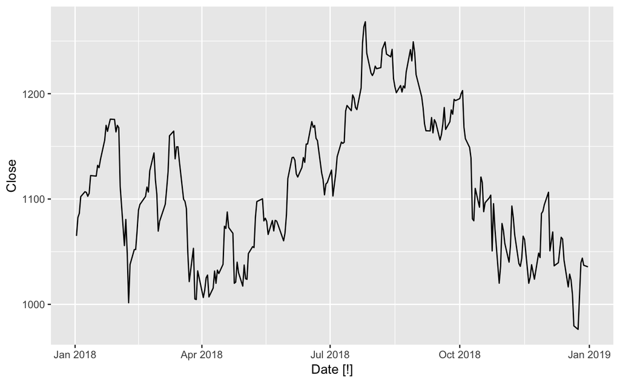

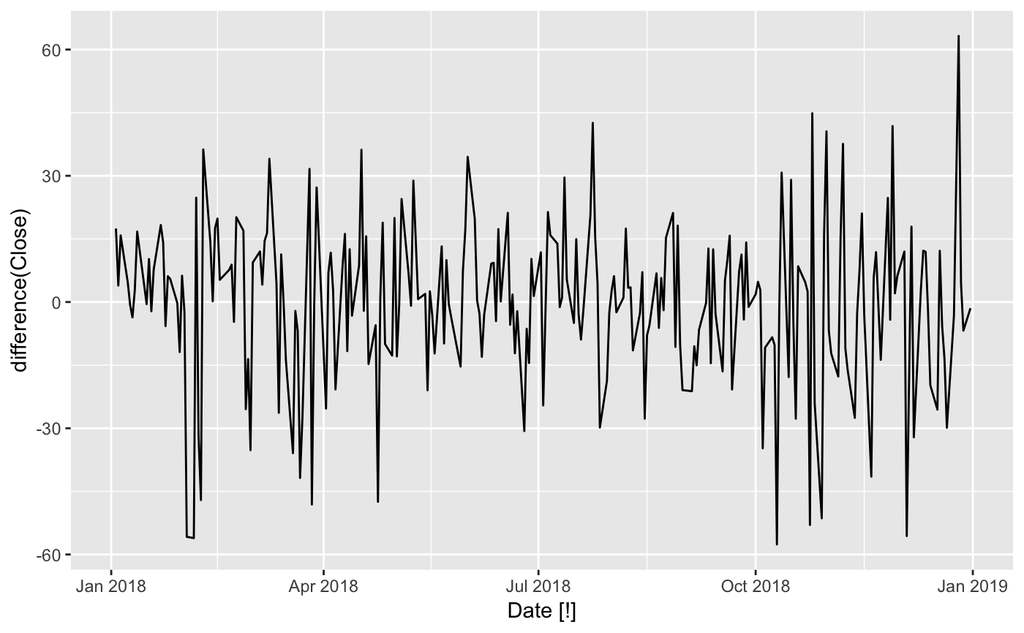

Differencing helps stabilize the mean.

Occasionaly, a second order difference is necessary.

automated ARIMA model selection achieved via stepwise selection. See lecture 8 slides.

# Lab session 16

For US GDP data, fit a suitable ARIMA model.

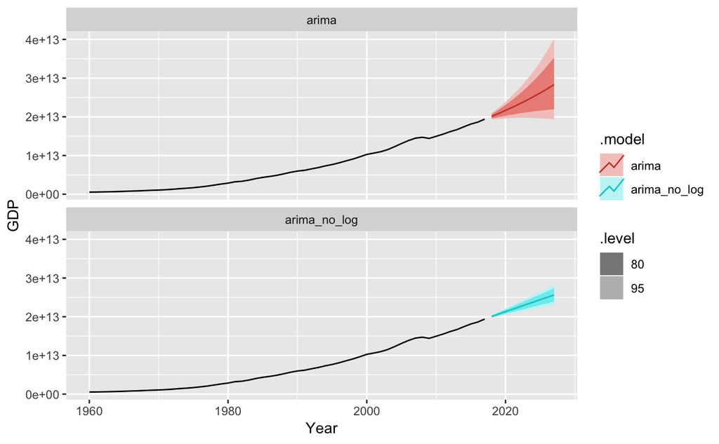

# Lab session 17

Fit a suitable ARIMA model for the “Holiday” data in `tourism`

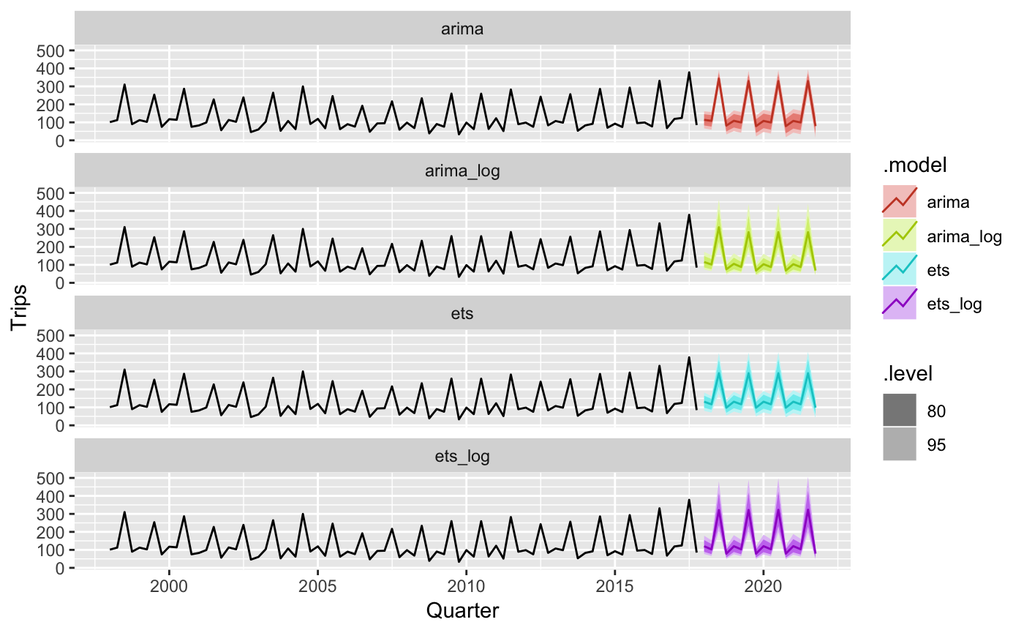

Consider Melbourne. The reason ARIMA models fail here is that Melbourne doesn’t show strong seasonality.

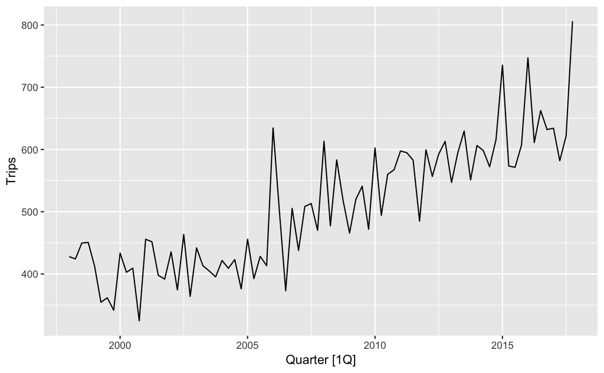

# Forecast ensembles

Simple syntax and handles distributional forecasts taking into account the correlations between the forecast errors of the component models.

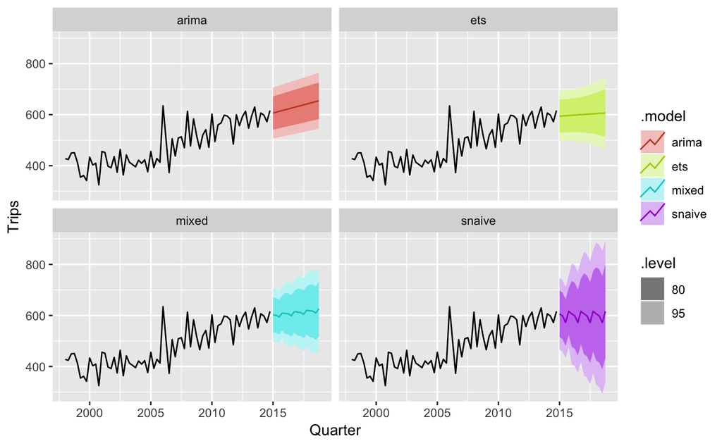

# Lab session 18

Use `I()` to specify knots in the formula call.

Compare AIC between similar AIC models paramaters(x,x,x)(x,x,x) must equal between differen models as Temperature varies.

# Dynamic Harmonic Regression

Combine Fourier terms with ARIMA errors

K can only be as high as the number of periods/2. E.g., 6 for monthly data, 26 for weekly data. This is because there are 2 coefficients per order K, thus, 2K = number of periods.

With increasing K, the ARIMA model becomes more simple (less degrees of freedom), because the Fourier terms handle more of the seasonal variance.